# Part I - (Ford go bike)

## Preliminary Wrangling

```python
import numpy as np
import pandas as pd
import matplotlib.pyplot as plt
import seaborn as sns
%matplotlib inline


file_path = "C:/Users/kyawt/OneDrive/Desktop/udacity data science project/201902-fordgobike-tripdata.csv"
df = pd.read_csv(file_path)
```

> Load in your dataset and describe its properties through the questions below. Try and motivate your exploration goals through this section.

```python
file_path = "C:/Users/kyawt/OneDrive/Desktop/udacity data science project/201902-fordgobike-tripdata.csv"
df = pd.read_csv(file_path)
```

### What is the structure of your dataset?

The dataset has 183412 rows and 16 columns.

### What is/are the main feature(s) of interest in your dataset?

Categorical columns: ['start_time', 'end_time', 'start_station_name', 'end_station_name', 'user_type', 'member_gender', 'bike_share_for_all_trip']

Numerical columns: ['duration_sec', 'start_station_id', 'start_station_latitude', 'start_station_longitude', 'end_station_id', 'end_station_latitude', 'end_station_longitude', 'bike_id', 'member_birth_year']

### What features in the dataset do you think will help support your investigation into your feature(s) of interest?

> Categorical columns

# The Structure of Dataset

```python
print(df.head())
```

```
   duration_sec                start_time                  end_time  \
0         52185  2019-02-28 17:32:10.1450  2019-03-01 08:01:55.9750
1         42521  2019-02-28 18:53:21.7890  2019-03-01 06:42:03.0560
2         61854  2019-02-28 12:13:13.2180  2019-03-01 05:24:08.1460
3         36490  2019-02-28 17:54:26.0100  2019-03-01 04:02:36.8420
4          1585  2019-02-28 23:54:18.5490  2019-03-01 00:20:44.0740

   start_station_id                                start_station_name  \
0              21.0  Montgomery St BART Station (Market St at 2nd St)
1              23.0                     The Embarcadero at Steuart St
2              86.0                           Market St at Dolores St
3             375.0                           Grove St at Masonic Ave
4               7.0                               Frank H Ogawa Plaza

   start_station_latitude  start_station_longitude  end_station_id  \
```

[output cut: 26 more lines]

```python
print(df.dtypes)
```

```
duration_sec                 int64
start_time                  object
end_time                    object
start_station_id           float64
start_station_name          object
start_station_latitude     float64
start_station_longitude    float64
end_station_id             float64
end_station_name            object
end_station_latitude       float64
end_station_longitude      float64
bike_id                      int64
user_type                   object
member_birth_year          float64
member_gender               object
bike_share_for_all_trip     object
dtype: object
```

```python
categorical_cols = df.select_dtypes(include=['object', 'category']).columns.tolist()

print("Categorical columns:", categorical_cols)
```

```
Categorical columns: ['start_time', 'end_time', 'start_station_name', 'end_station_name', 'user_type', 'member_gender', 'bike_share_for_all_trip']
```

```python
numerical_cols = df.select_dtypes(include=['int', 'float']).columns.tolist()

print("Numerical columns:", numerical_cols)
```

```
Numerical columns: ['duration_sec', 'start_station_id', 'start_station_latitude', 'start_station_longitude', 'end_station_id', 'end_station_latitude', 'end_station_longitude', 'bike_id', 'member_birth_year']
```

```python
print("Number of rows:", df.shape[0])
print("Number of columns:", df.shape[1])
```

```
Number of rows: 183412
Number of columns: 16
```

## Univariate Exploration

> In this section, investigate distributions of individual variables. If you see unusual points or outliers, take a deeper look to clean things up and prepare yourself to look at relationships between variables.

> **Rubric Tip**: The project (Parts I alone) should have at least 15 visualizations distributed over univariate, bivariate, and multivariate plots to explore many relationships in the data set. Use reasoning to justify the flow of the exploration.

> **Rubric Tip**: Use the "Question-Visualization-Observations" framework throughout the exploration. This framework involves **asking a question from the data, creating a visualization to find answers, and then recording observations after each visualisation.**

> **Rubric Tip**: Visualizations should depict the data appropriately so that the plots are easily interpretable. You should choose an appropriate plot type, data encodings, and formatting as needed. The formatting may include setting/adding the title, labels, legend, and comments. Also, do not overplot or incorrectly plot ordinal data.

### Discuss the distribution(s) of your variable(s) of interest. Were there any unusual points? Did you need to perform any transformations?

> I didn't need to since data type're in line with column names. It is easy to compare variables because of the data column names and data types each column represents.

### Of the features you investigated, were there any unusual distributions? Did you perform any operations on the data to tidy, adjust, or change the form of the data? If so, why did you do this?

> Data type fits with data column names.

# How many trips were taken by each user type (Subscriber and Customer)?

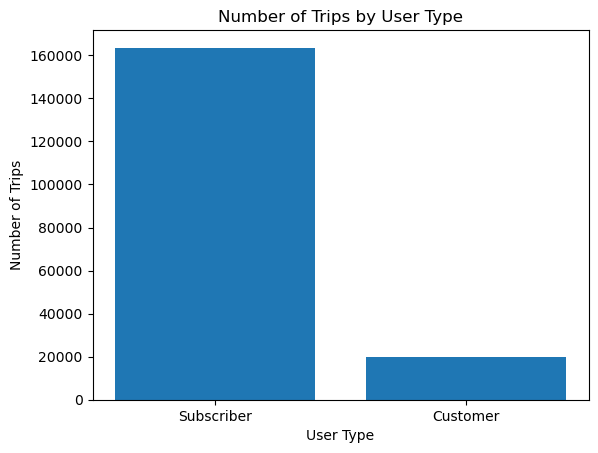

```python
user_type_counts = df['user_type'].value_counts()

plt.bar(user_type_counts.index, user_type_counts.values)
plt.xlabel('User Type')
plt.ylabel('Number of Trips')
plt.title('Number of Trips by User Type')
plt.show()
```

Subscribers have more number of trips than customer.

# What is the distribution of member genders (Male, Female, Other)?

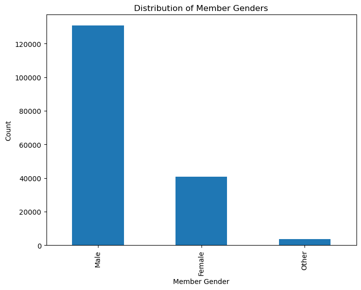

```python
gender_counts = df['member_gender'].value_counts()
plt.figure(figsize=(8, 6))
gender_counts.plot(kind='bar')
plt.xlabel('Member Gender')
plt.ylabel('Count')
plt.title('Distribution of Member Genders')
plt.show()
```

Male is the most popular genders.

# Which start stations are most frequently used for trips (based on start_station_id or start_station_name)?

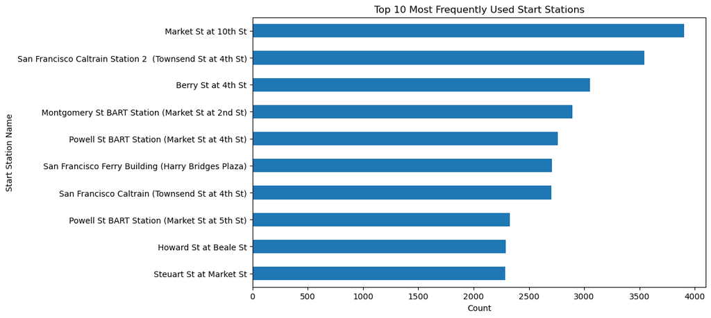

```python
top_start_stations = df['start_station_name'].value_counts().head(10)

plt.figure(figsize=(10, 6))
top_start_stations.plot(kind='barh')
plt.xlabel('Count')
plt.ylabel('Start Station Name')
plt.title('Top 10 Most Frequently Used Start Stations')

plt.gca().invert_yaxis()

plt.show()
```

Market St/ 10tth st, Towsend St/4th st, Berry St/4th St - They're the most popular start stations for bikers.

# Which end stations are most frequently used for trips (based on end_station_id or end_station_name)?

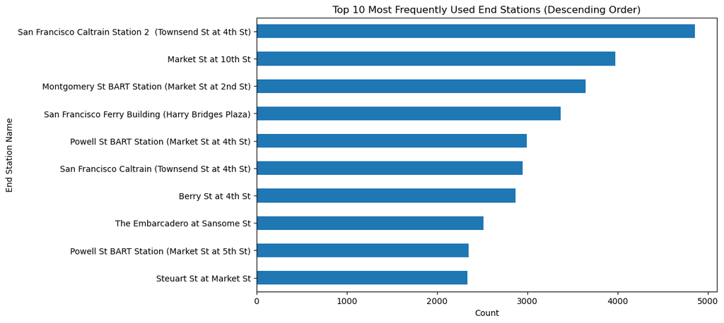

```python
top_end_stations = df['end_station_name'].value_counts().head(10)

top_end_stations_sorted = top_end_stations.sort_values(ascending=True)

plt.figure(figsize=(10, 6))
top_end_stations_sorted.plot(kind='barh')
plt.ylabel('End Station Name')
plt.xlabel('Count')
plt.title('Top 10 Most Frequently Used End Stations (Descending Order)')

plt.show()
```

The most popular end stations - Towsend/4th St, Market/10th st, Market/2nd St.

# What are the most common start times for trips (based on start_time)?

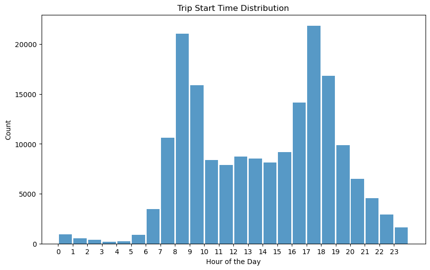

```python
df['start_time'] = pd.to_datetime(df['start_time'])

df['start_hour'] = df['start_time'].dt.hour

plt.figure(figsize=(10, 6))
plt.hist(df['start_hour'], bins=np.arange(0, 25, 1), alpha=0.75, rwidth=0.9)
plt.xlabel('Hour of the Day')
plt.ylabel('Count')
plt.title('Trip Start Time Distribution')

plt.xticks(np.arange(0, 24, 1))

plt.show()
```

Between 8-9 and 17-18(5pm-6pm), people start their trips the most.

## Bivariate Exploration

> In this section, investigate relationships between pairs of variables in your data. Make sure the variables that you cover here have been introduced in some fashion in the previous section (univariate exploration).

### Did you observe any interesting relationships between the other features (not the main feature(s) of interest)?

# What is the relationship between member gender (Male, Female, Other) and trip count?

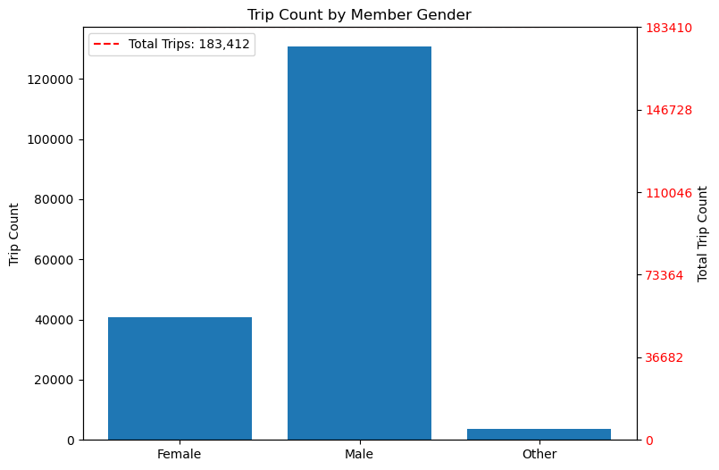

```python
gender_counts = df.groupby("member_gender").size()

fig, ax1 = plt.subplots(figsize=(8, 6))

bar_chart = ax1.bar(gender_counts.index, gender_counts.values)

ax1.set_ylabel("Trip Count")
ax1.set_title("Trip Count by Member Gender")

ax2 = ax1.twinx()

total_trips = df.shape[0]
line_chart = ax2.plot([0, len(gender_counts.index) - 1], [total_trips, total_trips], color="red", linestyle="--")

ax2.set_ylabel("Total Trip Count")
ax2.set_ylim(0, total_trips)
ax2.set_yticks(range(0, total_trips + 1, int(total_trips / 5)))
ax2.tick_params(axis="y", labelcolor="red")

line_label = "Total Trips: {:,}".format(total_trips)
ax2.legend(line_chart, [line_label], loc="upper left")

plt.show()
```

Male gender uses bikes the most. Male has the highest number of trip counts, followed by female, and other.